# Incarceration Report

Alex Cao

2022-11-21

## Section 1: Introduction

When I am asked where would be a good place to live, I usually consider the prosperity and security of the region at the first place, and something that would directly reflect the security level of a region is its crime rate. This huge data collected by Vera would be the main source we will be studying here and we will find out how the crime rate has changed over time and what might be certain factors that influence crime rate at certain time. With the result of this study, people could have a better idea on the distribution of crime geographically or ethnically.

## Section 2: Data Summary

Here we have a few questions:

- What is the national proportion of male prisoner population out of total jail population in year 2018? The proportion is 0.8413052.
- What is the national crime rate in 1970 and 2018?(Crime rate is jail pop/total pop) The crime rate in 1970 is 7.8833258^{-4}, while in 2018 crime rate is 0.0022531, which significantly increases.
- Which state has the biggest jail population? California has the biggest jail population.

## Section 3:

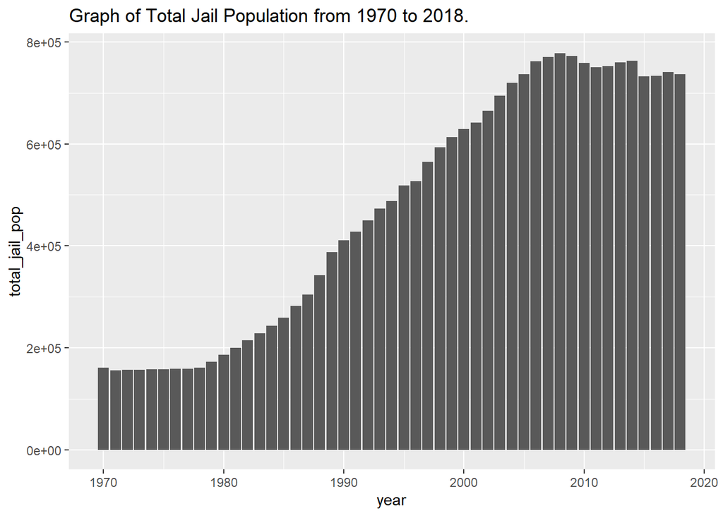

## Section 5

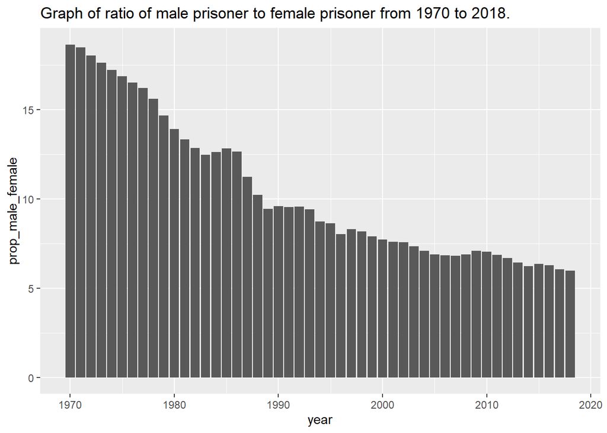

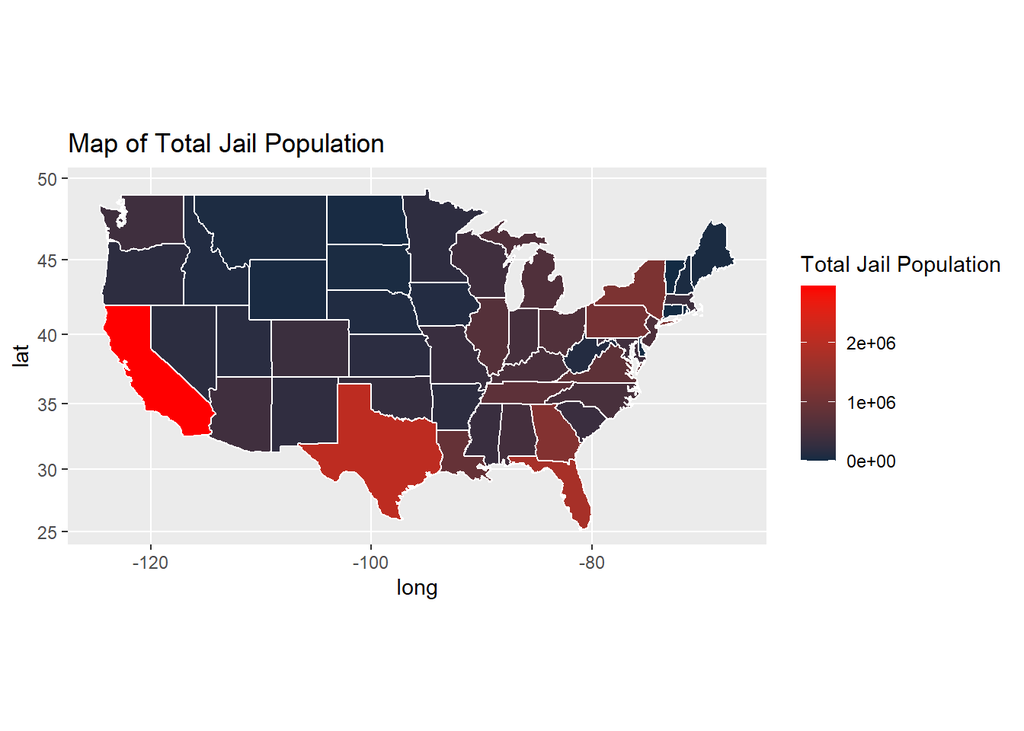

This is a map that demonstrates the jail population in different states in the U.S. The different color indicates the different level of total jail population, the more toward red meaning more population while the darker it is, the less population it is. As we can see, California, Texas and a lot of east states tend to have higher jail population. And a concise question would be that what could be a potential factor that is causing the difference between states?